# Outliers avec approche multivariée

```
## [1] 183928     41
```

```
##  [1] "X.1"                 "X"                   "Timestamp"
##  [4] "Site_ID"             "Warning_flags"       "Subclass_ID"
##  [7] "Axle_groups"         "A1"                  "A2"
## [10] "A3"                  "A4"                  "A5"
## [13] "A6"                  "A7"                  "Date"
## [16] "Horaire"             "Annee"               "Mois_num"
## [19] "Mois_annee"          "Jour_num"            "Jour_semaine"
## [22] "Heure"               "M1"                  "M2"
## [25] "M3"                  "M4"                  "M5"
## [28] "M6"                  "M7"                  "M8"
## [31] "Lane"                "N"                   "Nb_axles"
## [34] "Anomalie"            "total_axle_dist"     "T"
## [37] "Reduced_chi_squared" "Time_num"            "Vitesse"
## [40] "MGV"                 "clusters_kmeans"
```

# Approche multivariée

Pour l’approche multivariée: + On cherche un modèle représentant les données, + puis avec ce modèle on définit les outliers comme les individus ayant une distance de Cook supérieure à 4 fois la distance de Cook moyenne.

La valeur 4 n’est pas une valeur fixe ou définitive.

De plus, d’autres approches peuvent être mises en place, par exemple avec les résidues, les hat values et les valeurs de r-student.

## Recherche du modèle avec caret

```
## 'data.frame':    1000 obs. of  19 variables:
##  $ A1                 : num  3.9 3.54 2.37 3.8 3.72 ...
##  $ A2                 : num  5.68 0 0 5.92 5.68 ...
##  $ A3                 : num  1.33 0 0 1.28 1.33 ...
##  $ A4                 : num  1.33 0 0 1.37 1.33 ...
##  $ A5                 : num  0 0 0 0 0 ...
##  $ A6                 : num  0 0 0 0 0 0 0 0 0 0 ...
##  $ A7                 : num  0 0 0 0 0 0 0 0 0 0 ...
##  $ M1                 : num  4.681 1.955 0.888 5.094 5.063 ...
##  $ M2                 : num  8.728 2.871 0.771 8.109 9.024 ...
##  $ M3                 : num  4.24 0 0 1.75 4.66 ...
##  $ M4                 : num  5.92 0 0 3.56 6.88 ...
##  $ M5                 : num  5.83 0 0 3.37 6.49 ...
##  $ M6                 : num  0 0 0 0 0 ...
##  $ M7                 : num  0 0 0 0 0 0 0 0 0 0 ...
##  $ M8                 : num  0 0 0 0 0 0 0 0 0 0 ...
##  $ N                  : num  5 2 2 5 5 5 5 6 5 5 ...
##  $ Vitesse            : num  76.4 74.1 74.1 81.5 68 ...
##  $ MGV                : num  29.39 4.83 1.66 21.89 32.12 ...
##  $ Reduced_chi_squared: num  391.59 4.25 13.85 401.02 521.62 ...
```

```
## [1] 0
```

```
## [1] 0
```

```
## [1] 0
```

```
## 'data.frame':    1000 obs. of  19 variables:
##  $ A1                 : num  -0.117 -0.49 -1.701 -0.216 -0.297 ...
##  $ A2                 : num  0.454 -1.801 -1.801 0.55 0.453 ...
##  $ A3                 : num  -0.0431 -1.0018 -1.0018 -0.0754 -0.0426 ...
##  $ A4                 : num  0.386 -0.896 -0.896 0.429 0.387 ...
##  $ A5                 : num  -0.18 -0.18 -0.18 -0.18 -0.18 ...
##  $ A6                 : num  -0.115 -0.115 -0.115 -0.115 -0.115 ...
##  $ A7                 : num  -0.0941 -0.0941 -0.0941 -0.0941 -0.0941 ...
##  $ M1                 : num  0.0765 -1.2348 -1.7481 0.2752 0.26 ...
##  $ M2                 : num  0.538 -0.987 -1.533 0.377 0.615 ...
##  $ M3                 : num  0.586 -1.098 -1.098 -0.404 0.75 ...
##  $ M4                 : num  0.8448 -1.0816 -1.0816 0.0782 1.1601 ...
##  $ M5                 : num  1.107 -0.839 -0.839 0.288 1.328 ...
##  $ M6                 : num  -0.133 -0.133 -0.133 -0.133 -0.133 ...
##  $ M7                 : num  -0.0543 -0.0543 -0.0543 -0.0543 -0.0543 ...
##  $ M8                 : num  0 0 0 0 0 0 0 0 0 0 ...
##  $ N                  : num  0.58 -1.93 -1.93 0.58 0.58 ...
##  $ Vitesse            : num  0.527 0.325 0.325 0.972 -0.216 ...
##  $ MGV                : num  0.70292 -1.61637 -1.91535 -0.00578 0.9598 ...
##  $ Reduced_chi_squared: num  -0.16211 -0.6591 -0.64679 -0.15 0.00473 ...
```

L’échantillon de données est coupé en deux, pour la pouplation d’apprentissage (75%) et celle de test (25%). Cela est fait facilement avec la fonction createDataPartition du package caret.

```
## 'data.frame':    752 obs. of  19 variables:
##  $ A1                 : num  -0.49 -0.297 -0.176 -0.377 0.703 ...
##  $ A2                 : num  -1.801 0.453 0.581 0.518 -1.242 ...
##  $ A3                 : num  -1.0018 -0.04255 0.01007 -0.00674 2.46748 ...
##  $ A4                 : num  -0.896 0.387 0.38 0.363 3.744 ...
##  $ A5                 : num  -0.18 -0.18 -0.18 -0.18 1.41 ...
##  $ A6                 : num  -0.115 -0.115 -0.115 -0.115 -0.115 ...
##  $ A7                 : num  -0.0941 -0.0941 -0.0941 -0.0941 -0.0941 ...
##  $ M1                 : num  -1.2348 0.26 0.0174 -0.096 0.4579 ...
##  $ M2                 : num  -0.987 0.615 0.509 0.217 0.121 ...
##  $ M3                 : num  -1.0983 0.75 0.0355 -0.1617 0.9465 ...
##  $ M4                 : num  -1.082 1.16 0.332 0.145 0.719 ...
##  $ M5                 : num  -0.839 1.328 0.485 0.262 -0.109 ...
##  $ M6                 : num  -0.133 -0.133 -0.133 -0.133 4.213 ...
##  $ M7                 : num  -0.0543 -0.0543 -0.0543 -0.0543 -0.0543 ...
##  $ M8                 : num  0 0 0 0 0 0 0 0 0 0 ...
##  $ N                  : num  -1.93 0.58 0.58 0.58 1.42 ...
##  $ Vitesse            : num  0.3247 -0.2155 0.2922 -0.16 -0.0164 ...
##  $ MGV                : num  -1.6164 0.9598 0.2256 -0.0667 0.5999 ...
##  $ Reduced_chi_squared: num  -0.6591 0.00473 -0.42772 -0.3609 0.1809 ...
```

On utilise la fonction rfe pour contrôler les features (ici validation croisée, avec 3 répétitions).

De plus, le calage de modèle est aussi contrôlée par validation croisée, avec 5 répétitions.

```
##
## Recursive feature selection
##
## Outer resampling method: Cross-Validated (10 fold, repeated 3 times)
##
## Resampling performance over subset size:
##
##  Variables   RMSE Rsquared    MAE  RMSESD RsquaredSD   MAESD Selected
##          4 0.3052   0.9096 0.1764 0.05704    0.03208 0.03143
##          8 0.1975   0.9651 0.1165 0.04725    0.01486 0.02167
##         16 0.1782   0.9706 0.1057 0.04816    0.01342 0.02056
##         18 0.1772   0.9708 0.1044 0.04754    0.01343 0.01981        *
##
## The top 5 variables (out of 18):
##    M2, M3, M5, M4, M1
```

```
##   [1] "ada"                 "AdaBag"              "AdaBoost.M1"
##   [4] "adaboost"            "amdai"               "ANFIS"
##   [7] "avNNet"              "awnb"                "awtan"
##  [10] "bag"                 "bagEarth"            "bagEarthGCV"
##  [13] "bagFDA"              "bagFDAGCV"           "bam"
##  [16] "bartMachine"         "bayesglm"            "binda"
##  [19] "blackboost"          "blasso"              "blassoAveraged"
##  [22] "bridge"              "brnn"                "BstLm"
##  [25] "bstSm"               "bstTree"             "C5.0"
##  [28] "C5.0Cost"            "C5.0Rules"           "C5.0Tree"
##  [31] "cforest"             "chaid"               "CSimca"
##  [34] "ctree"               "ctree2"              "cubist"
##  [37] "dda"                 "deepboost"           "DENFIS"
##  [40] "dnn"                 "dwdLinear"           "dwdPoly"
##  [43] "dwdRadial"           "earth"               "elm"
```

[output cut: 65 more lines]

Les modèles recherchés sont le modèle linéaire généralisé, celui avec pénalisation Lasso, les forêts aléatoires, et les gradient boosting.

## Modèle linéaire généralisé

[figure not shown]

## Modèle linéaire généralisé avec pénalisation Lasso

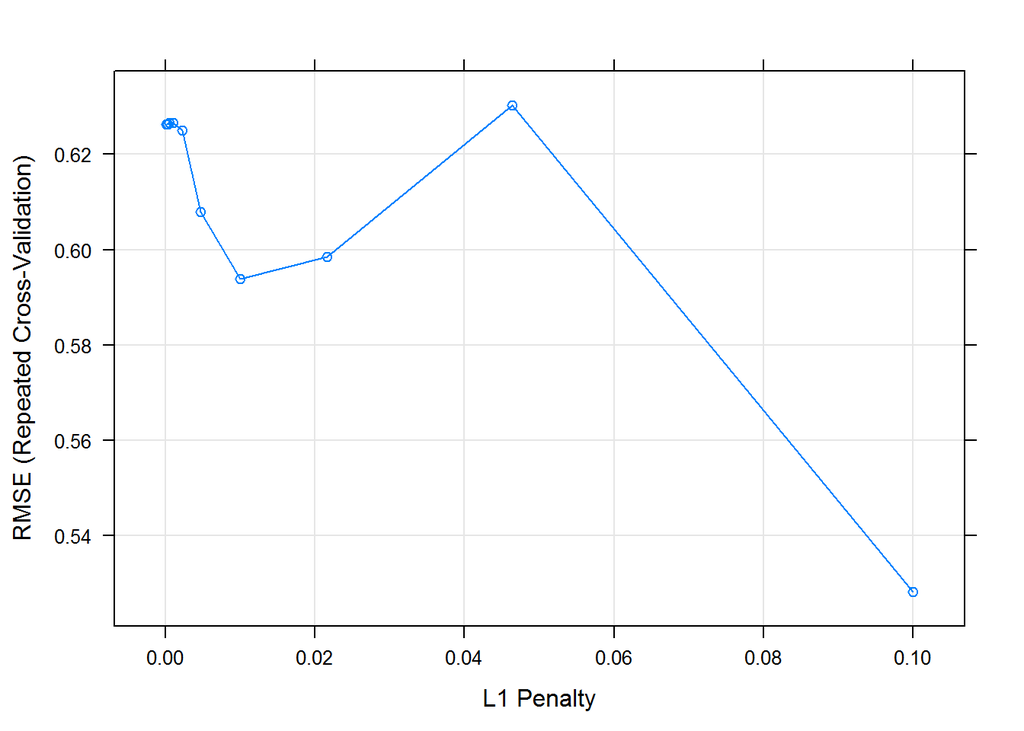

## Forêts aléatoires

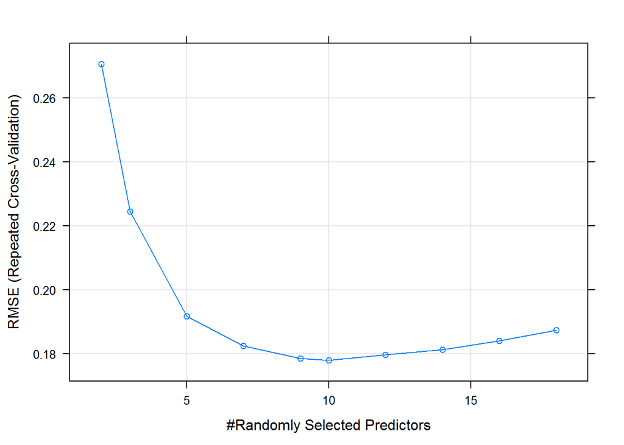

## Gradient boosting

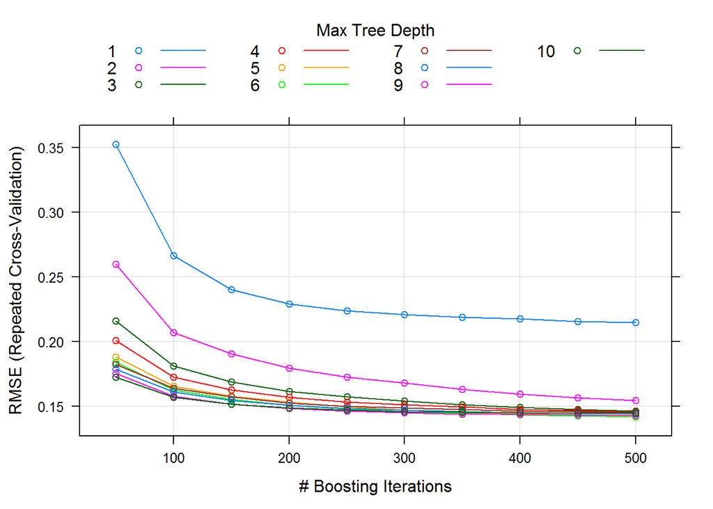

## Comparaison des différents modèles

| Resample | mod.rf~MAE | mod.rf~RMSE | mod.rf~Rsquared | mod.glm~MAE | mod.glm~RMSE | mod.glm~Rsquared | mod.rqlasso~MAE | mod.rqlasso~RMSE | mod.rqlasso~Rsquared | mod.gbm~MAE | mod.gbm~RMSE | mod.gbm~Rsquared |
| --- | --- | --- | --- | --- | --- | --- | --- | --- | --- | --- | --- | --- |
| Fold1.Rep1 | 0.11736157 | 0.2295753 | 0.9539113 | 0.08841195 | 0.1406426 | 0.9812468 | 0.2381853 | 0.5355516 | 0.7330388 | 0.07597622 | 0.12133477 | 0.9855138 |
| Fold1.Rep2 | 0.08329944 | 0.1295058 | 0.9827679 | 0.07797253 | 0.1188929 | 0.9839571 | 0.2146293 | 0.4686832 | 0.7881229 | 0.08908996 | 0.15416236 | 0.9760086 |
| Fold1.Rep3 | 0.10022711 | 0.1682498 | 0.9756824 | 0.09400027 | 0.1523763 | 0.9785281 | 0.2118740 | 0.4568959 | 0.8086516 | 0.08415683 | 0.16572455 | 0.9742149 |
| Fold1.Rep4 | 0.10573775 | 0.1852248 | 0.9702731 | 0.07984380 | 0.1295612 | 0.9820453 | 0.3046766 | 0.6210337 | 0.6631717 | 0.08350851 | 0.13442988 | 0.9806734 |
| Fold1.Rep5 | 0.10809708 | 0.1863286 | 0.9623884 | 0.07596514 | 0.1067195 | 0.9881286 | 0.1853517 | 0.4135993 | 0.8351827 | 0.07501083 | 0.11589748 | 0.9886042 |
| Fold2.Rep1 | 0.08064223 | 0.1264721 | 0.9833669 | 0.10532697 | 0.1883847 | 0.9684884 | 0.1979998 | 0.4102088 | 0.8304099 | 0.08587266 | 0.14603926 | 0.9776149 |
| Fold2.Rep2 | 0.10442806 | 0.1682377 | 0.9726972 | 0.07622477 | 0.1323136 | 0.9820325 | 0.1792243 | 0.3811960 | 0.8580126 | 0.07461350 | 0.12116987 | 0.9849176 |
| Fold2.Rep3 | 0.11981750 | 0.2465154 | 0.9426969 | 0.07628081 | 0.1198221 | 0.9854050 | 0.2149864 | 0.5008665 | 0.7615089 | 0.08477639 | 0.13631388 | 0.9809351 |
| Fold2.Rep4 | 0.10195711 | 0.1714026 | 0.9724360 | 0.09442792 | 0.1596072 | 0.9750578 | 0.1969082 | 0.5021727 | 0.7643987 | 0.08940785 | 0.15481249 | 0.9766059 |
| Fold2.Rep5 | 0.09181954 | 0.1537256 | 0.9739552 | 0.10173411 | 0.1774697 | 0.9724047 | 0.2835384 | 0.6114881 | 0.6645858 | 0.07523998 | 0.10628067 | 0.9876194 |

[output cut: 15 more lines]

[output not shown]

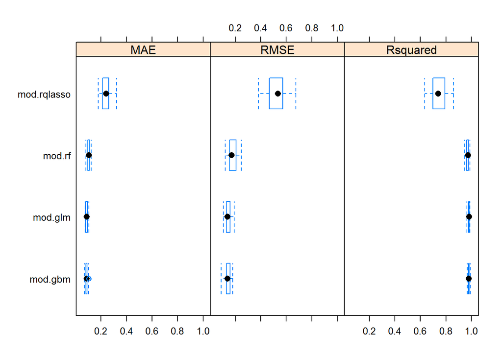

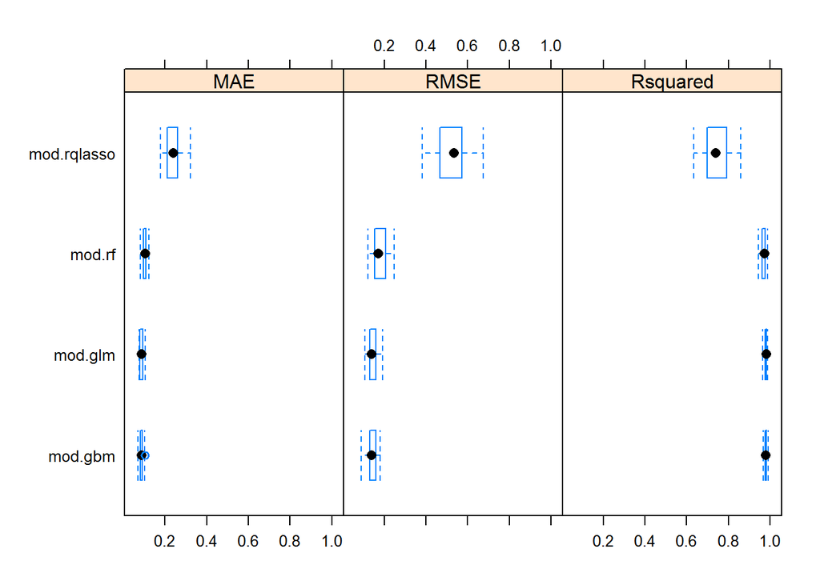

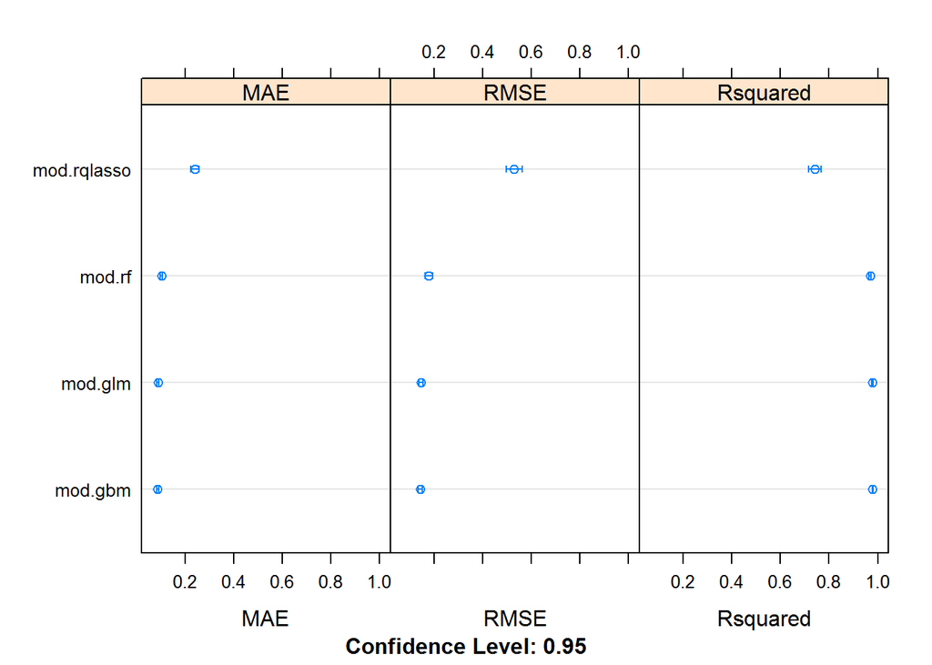

```
##    user  system elapsed
## 1119.54   11.67 1190.87
```

## Recherche des outliers

Nous recherchons le modèle linéaire généralisé avec toutes les données, et en utilisant la fonction glm de R base.

```
##  [1] "Warning_flags"       "A1"                  "A2"
##  [4] "A3"                  "A4"                  "A5"
##  [7] "A6"                  "A7"                  "M1"
## [10] "M2"                  "M3"                  "M4"
## [13] "M5"                  "M6"                  "M7"
## [16] "M8"                  "N"                   "Reduced_chi_squared"
## [19] "Vitesse"             "MGV"                 "clusters_kmeans"
```

### Avec les résidus

Une règle approximative consiste à dire que les données aberrantes sont les individus avec un résidus standardisés supérieurs à 3.3 (correspondant à un niveau de $\alpha$ de .001).

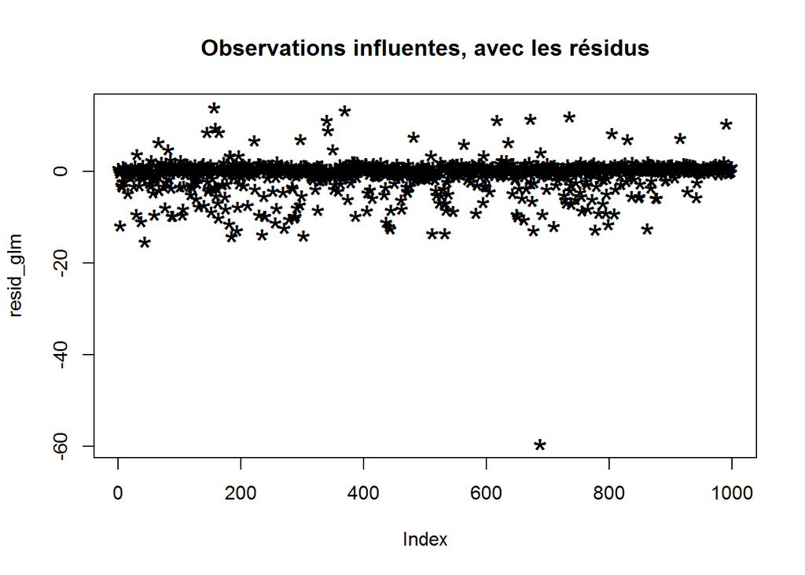

|  | Warning_flags | A1 | A2 | A3 | A4 | A5 | A6 | A7 | M1 | M2 | M3 | M4 | M5 | M6 | M7 | M8 | N | Reduced_chi_squared | Vitesse | MGV | clusters_kmeans |
| --- | --- | --- | --- | --- | --- | --- | --- | --- | --- | --- | --- | --- | --- | --- | --- | --- | --- | --- | --- | --- | --- |
| 182929 | 00000000 | 5.04615 | 0.00000 | 0.00000 | 0.00000 | 0.00000 | 0.00000 | 0.00000 | 4.342477 | 10.082803 | 0.000000 | 0.000000 | 0.000000 | 0 | 0 | 0 | 2.000000 | 99.1364 | 75.61836 | 14.425280 | 1 |
| 182930 | 00000000 | 4.14973 | 0.00000 | 0.00000 | 0.00000 | 0.00000 | 0.00000 | 0.00000 | 3.459867 | 2.630398 | 0.000000 | 0.000000 | 0.000000 | 0 | 0 | 0 | 2.000000 | 975.9530 | 78.85332 | 6.090265 | 1 |
| 182931 | 00000000 | 3.87629 | 5.81443 | 1.40206 | 1.44330 | 0.00000 | 0.00000 | 0.00000 | 5.646993 | 5.451519 | 3.483364 | 3.483364 | 3.483364 | 0 | 0 | 0 | 5.000000 | 532.4190 | 76.00824 | 21.548624 | 3 |
| 182932 | 00000080 | 9.50303 | 1.79394 | 3.29697 | 4.41212 | 9.35758 | 2.81212 | 5.91515 | 0.000000 | 0.000000 | 0.000000 | 0.000000 | 0.000000 | 0 | 0 | 0 | 3.202917 | 46.6236 | 89.36712 | 7.072423 | 1 |
| 182933 | 00800000 | 3.75451 | 5.86282 | 1.32852 | 1.29964 | 0.00000 | 0.00000 | 0.00000 | 5.816453 | 10.481651 | 10.524465 | 10.524465 | 10.524465 | 0 | 0 | 0 | 5.000000 | 1444.5800 | 53.23320 | 47.871356 | 2 |
| 182934 | 00800000 | 3.84937 | 5.89121 | 1.37238 | 1.30544 | 0.00000 | 0.00000 | 0.00000 | 5.182793 | 12.514883 | 8.937421 | 8.937421 | 8.937421 | 0 | 0 | 0 | 5.000000 | 3905.0300 | 61.69716 | 44.509888 | 2 |

### Avec la distance de Cook

La distance de Cook est essentiellement une mesure de distance standardisée qui permet de décrire le changement dans l’estimateur de $\beta$ lorsque l’on retire l’observation $i$. Une grande valeur de la distance de Cook suggère que l’observation i possède une grande influence.

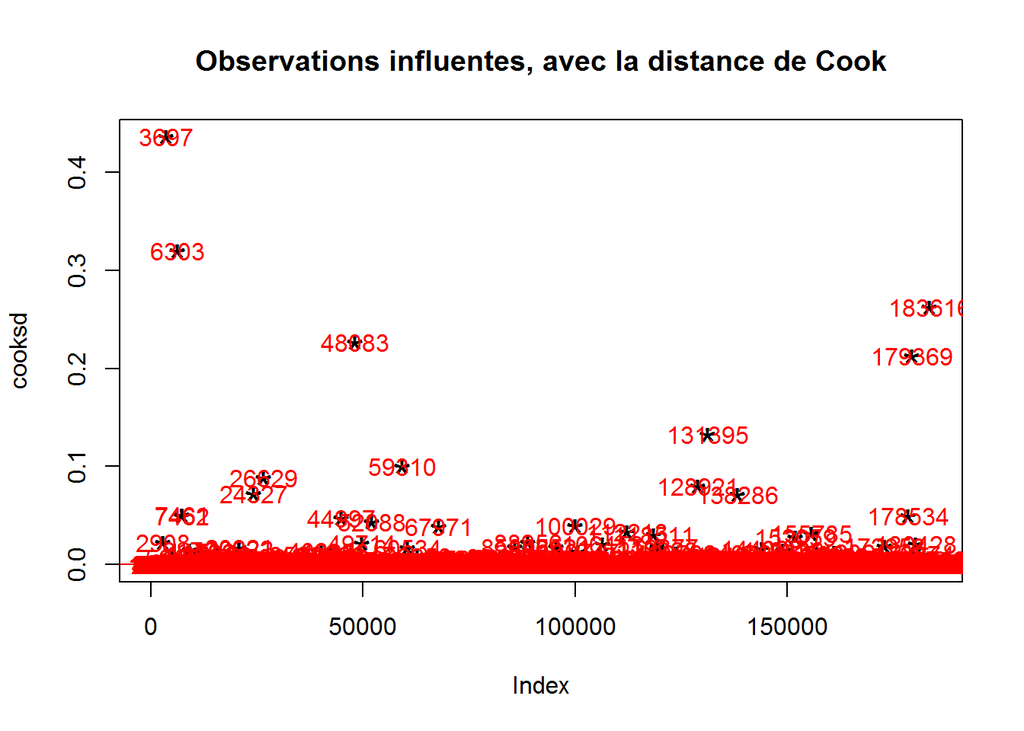

|  | Warning_flags | A1 | A2 | A3 | A4 | A5 | A6 | A7 | M1 | M2 | M3 | M4 | M5 | M6 | M7 | M8 | N | Reduced_chi_squared | Vitesse | MGV | clusters_kmeans | outlier |
| --- | --- | --- | --- | --- | --- | --- | --- | --- | --- | --- | --- | --- | --- | --- | --- | --- | --- | --- | --- | --- | --- | --- |
| 149 | 00000080 | 1.58454 | 0.00000 | 0.00000 | 0.00000 | 0.00000 | 0 | 0 | 0.000000 | 0.000000 | 0.00000 | 0.00000 | 0.00000 | 0 | 0 | 0 | 2 | 22.7692 | 71.23464 | 7.299760 | 1 | FALSE |
| 228 | 00800001 | 3.81818 | 5.90909 | 1.31818 | 1.36364 | 0.00000 | 0 | 0 | 3.698695 | 3.695301 | 11.05566 | 23.14027 | 9.84472 | 0 | 0 | 0 | 5 | 818.1960 | 83.78172 | 51.434659 | 2 | FALSE |
| 430 | 00000081 | 1.54455 | 0.00000 | 0.00000 | 0.00000 | 0.00000 | 0 | 0 | 0.000000 | 0.000000 | 0.00000 | 0.00000 | 0.00000 | 0 | 0 | 0 | 2 | 314.3470 | 72.99792 | 5.605030 | 1 | FALSE |
| 433 | 00000081 | 1.62376 | 0.00000 | 0.00000 | 0.00000 | 0.00000 | 0 | 0 | 0.000000 | 0.000000 | 0.00000 | 0.00000 | 0.00000 | 0 | 0 | 0 | 2 | 314.3470 | 72.99792 | 5.640992 | 1 | FALSE |
| 504 | 00000080 | 4.80000 | 0.00000 | 0.00000 | 0.00000 | 0.00000 | 0 | 0 | 0.000000 | 0.000000 | 0.00000 | 0.00000 | 0.00000 | 0 | 0 | 0 | 2 | 17.2207 | 89.36712 | 3.451024 | 1 | FALSE |
| 506 | 00000080 | 4.00000 | 4.40000 | 1.22857 | 1.22857 | 7.77143 | 0 | 0 | 0.000000 | 0.000000 | 0.00000 | 0.00000 | 0.00000 | 0 | 0 | 0 | 6 | 429.8350 | 52.66296 | 31.173128 | 2 | FALSE |

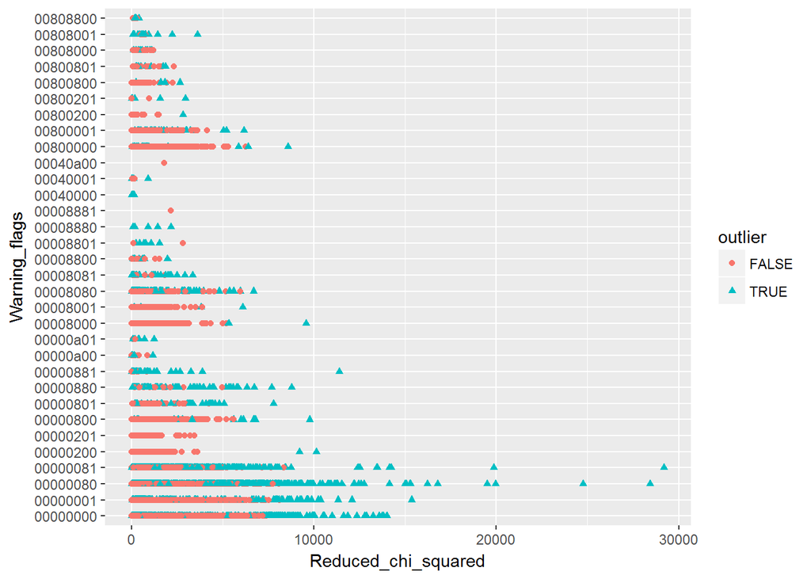

### Avec les hat values

La statistique de leverage (leverage points = points influents), $h$, aussi appelée hat value (issue de la hat matrice, aussi appelée matrice de projection), identfie les individus qui influencent plus la line de régression que les autres.

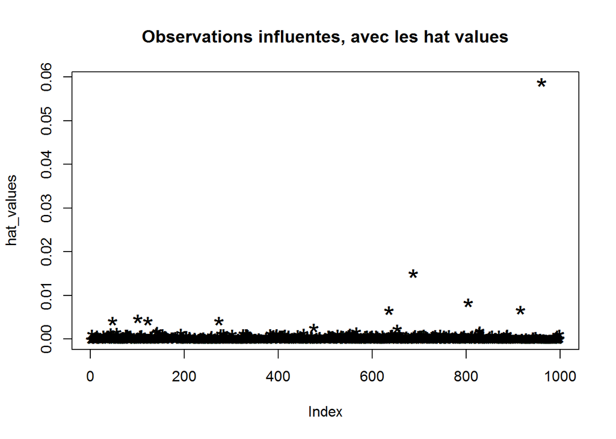

|  | Warning_flags | A1 | A2 | A3 | A4 | A5 | A6 | A7 | M1 | M2 | M3 | M4 | M5 | M6 | M7 | M8 | N | Reduced_chi_squared | Vitesse | MGV | clusters_kmeans | outlier |
| --- | --- | --- | --- | --- | --- | --- | --- | --- | --- | --- | --- | --- | --- | --- | --- | --- | --- | --- | --- | --- | --- | --- |
| 182929 | 00000000 | 5.04615 | 0.00000 | 0.00000 | 0.00000 | 0.00000 | 0.00000 | 0.00000 | 4.342477 | 10.082803 | 0.000000 | 0.000000 | 0.000000 | 0 | 0 | 0 | 2.000000 | 99.1364 | 75.61836 | 14.425280 | 1 | FALSE |
| 182930 | 00000000 | 4.14973 | 0.00000 | 0.00000 | 0.00000 | 0.00000 | 0.00000 | 0.00000 | 3.459867 | 2.630398 | 0.000000 | 0.000000 | 0.000000 | 0 | 0 | 0 | 2.000000 | 975.9530 | 78.85332 | 6.090265 | 1 | FALSE |
| 182931 | 00000000 | 3.87629 | 5.81443 | 1.40206 | 1.44330 | 0.00000 | 0.00000 | 0.00000 | 5.646993 | 5.451519 | 3.483364 | 3.483364 | 3.483364 | 0 | 0 | 0 | 5.000000 | 532.4190 | 76.00824 | 21.548624 | 3 | FALSE |
| 182932 | 00000080 | 9.50303 | 1.79394 | 3.29697 | 4.41212 | 9.35758 | 2.81212 | 5.91515 | 0.000000 | 0.000000 | 0.000000 | 0.000000 | 0.000000 | 0 | 0 | 0 | 3.202917 | 46.6236 | 89.36712 | 7.072423 | 1 | TRUE |
| 182933 | 00800000 | 3.75451 | 5.86282 | 1.32852 | 1.29964 | 0.00000 | 0.00000 | 0.00000 | 5.816453 | 10.481651 | 10.524465 | 10.524465 | 10.524465 | 0 | 0 | 0 | 5.000000 | 1444.5800 | 53.23320 | 47.871356 | 2 | FALSE |
| 182934 | 00800000 | 3.84937 | 5.89121 | 1.37238 | 1.30544 | 0.00000 | 0.00000 | 0.00000 | 5.182793 | 12.514883 | 8.937421 | 8.937421 | 8.937421 | 0 | 0 | 0 | 5.000000 | 3905.0300 | 61.69716 | 44.509888 | 2 | FALSE |

### Avec les résidus de r-student

Un résidu studentisé est le résidu observé divisé par l’écart-type.

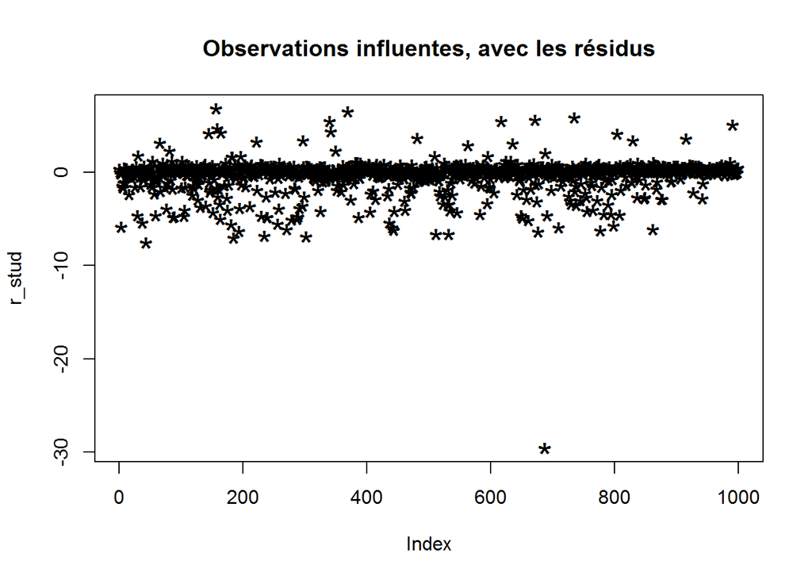

|  | Warning_flags | A1 | A2 | A3 | A4 | A5 | A6 | A7 | M1 | M2 | M3 | M4 | M5 | M6 | M7 | M8 | N | Reduced_chi_squared | Vitesse | MGV | clusters_kmeans | outlier |
| --- | --- | --- | --- | --- | --- | --- | --- | --- | --- | --- | --- | --- | --- | --- | --- | --- | --- | --- | --- | --- | --- | --- |
| 182929 | 00000000 | 5.04615 | 0.00000 | 0.00000 | 0.00000 | 0.00000 | 0.00000 | 0.00000 | 4.342477 | 10.082803 | 0.000000 | 0.000000 | 0.000000 | 0 | 0 | 0 | 2.000000 | 99.1364 | 75.61836 | 14.425280 | 1 | TRUE |
| 182930 | 00000000 | 4.14973 | 0.00000 | 0.00000 | 0.00000 | 0.00000 | 0.00000 | 0.00000 | 3.459867 | 2.630398 | 0.000000 | 0.000000 | 0.000000 | 0 | 0 | 0 | 2.000000 | 975.9530 | 78.85332 | 6.090265 | 1 | TRUE |
| 182931 | 00000000 | 3.87629 | 5.81443 | 1.40206 | 1.44330 | 0.00000 | 0.00000 | 0.00000 | 5.646993 | 5.451519 | 3.483364 | 3.483364 | 3.483364 | 0 | 0 | 0 | 5.000000 | 532.4190 | 76.00824 | 21.548624 | 3 | TRUE |
| 182932 | 00000080 | 9.50303 | 1.79394 | 3.29697 | 4.41212 | 9.35758 | 2.81212 | 5.91515 | 0.000000 | 0.000000 | 0.000000 | 0.000000 | 0.000000 | 0 | 0 | 0 | 3.202917 | 46.6236 | 89.36712 | 7.072423 | 1 | TRUE |
| 182933 | 00800000 | 3.75451 | 5.86282 | 1.32852 | 1.29964 | 0.00000 | 0.00000 | 0.00000 | 5.816453 | 10.481651 | 10.524465 | 10.524465 | 10.524465 | 0 | 0 | 0 | 5.000000 | 1444.5800 | 53.23320 | 47.871356 | 2 | TRUE |
| 182934 | 00800000 | 3.84937 | 5.89121 | 1.37238 | 1.30544 | 0.00000 | 0.00000 | 0.00000 | 5.182793 | 12.514883 | 8.937421 | 8.937421 | 8.937421 | 0 | 0 | 0 | 5.000000 | 3905.0300 | 61.69716 | 44.509888 | 2 | TRUE |